# Pràctica 2

Aida Berenguer

# 1. Descripció del dataset

```r
# Càrrega de les llibreries necessaries
library(ggplot2)
library(corrplot)
library(ggpubr)
library(factoextra)
library(cluster)
```

```r
# Lectura de les dades dels fitxers csv
red_wine <- read.csv('winequality-red.csv')
white_wine <- read.csv('winequality-white.csv', sep = ';')

# Mostra les primeres files dels data.frames
head(red_wine)
```

|  | fixed.acidity | volatile.acidity | citric.acid | residual.sugar | chlorides | free.sulfur.dioxide | total.sulfur.dioxide | density | pH | sulphates | alcohol | quality |
| --- | --- | --- | --- | --- | --- | --- | --- | --- | --- | --- | --- | --- |
| 1 | 7.4 | 0.70 | 0.00 | 1.9 | 0.076 | 11 | 34 | 0.9978 | 3.51 | 0.56 | 9.4 | 5 |
| 2 | 7.8 | 0.88 | 0.00 | 2.6 | 0.098 | 25 | 67 | 0.9968 | 3.20 | 0.68 | 9.8 | 5 |
| 3 | 7.8 | 0.76 | 0.04 | 2.3 | 0.092 | 15 | 54 | 0.9970 | 3.26 | 0.65 | 9.8 | 5 |
| 4 | 11.2 | 0.28 | 0.56 | 1.9 | 0.075 | 17 | 60 | 0.9980 | 3.16 | 0.58 | 9.8 | 6 |
| 5 | 7.4 | 0.70 | 0.00 | 1.9 | 0.076 | 11 | 34 | 0.9978 | 3.51 | 0.56 | 9.4 | 5 |
| 6 | 7.4 | 0.66 | 0.00 | 1.8 | 0.075 | 13 | 40 | 0.9978 | 3.51 | 0.56 | 9.4 | 5 |

```r
head(white_wine)
```

|  | fixed.acidity | volatile.acidity | citric.acid | residual.sugar | chlorides | free.sulfur.dioxide | total.sulfur.dioxide | density | pH | sulphates | alcohol | quality |
| --- | --- | --- | --- | --- | --- | --- | --- | --- | --- | --- | --- | --- |
| 1 | 7.0 | 0.27 | 0.36 | 20.7 | 0.045 | 45 | 170 | 1.0010 | 3.00 | 0.45 | 8.8 | 6 |
| 2 | 6.3 | 0.30 | 0.34 | 1.6 | 0.049 | 14 | 132 | 0.9940 | 3.30 | 0.49 | 9.5 | 6 |
| 3 | 8.1 | 0.28 | 0.40 | 6.9 | 0.050 | 30 | 97 | 0.9951 | 3.26 | 0.44 | 10.1 | 6 |
| 4 | 7.2 | 0.23 | 0.32 | 8.5 | 0.058 | 47 | 186 | 0.9956 | 3.19 | 0.40 | 9.9 | 6 |
| 5 | 7.2 | 0.23 | 0.32 | 8.5 | 0.058 | 47 | 186 | 0.9956 | 3.19 | 0.40 | 9.9 | 6 |
| 6 | 8.1 | 0.28 | 0.40 | 6.9 | 0.050 | 30 | 97 | 0.9951 | 3.26 | 0.44 | 10.1 | 6 |

```r
# Comprova les dimensions dels data.frames
dim(red_wine)
```

```
## [1] 1599   12
```

```r
dim(white_wine)
```

```
## [1] 4898   12
```

```r
# Comprova l'estructura dels data.frames
str(red_wine)
```

```
## 'data.frame':    1599 obs. of  12 variables:
##  $ fixed.acidity       : num  7.4 7.8 7.8 11.2 7.4 7.4 7.9 7.3 7.8 7.5 ...
##  $ volatile.acidity    : num  0.7 0.88 0.76 0.28 0.7 0.66 0.6 0.65 0.58 0.5 ...
##  $ citric.acid         : num  0 0 0.04 0.56 0 0 0.06 0 0.02 0.36 ...
##  $ residual.sugar      : num  1.9 2.6 2.3 1.9 1.9 1.8 1.6 1.2 2 6.1 ...
##  $ chlorides           : num  0.076 0.098 0.092 0.075 0.076 0.075 0.069 0.065 0.073 0.071 ...
##  $ free.sulfur.dioxide : num  11 25 15 17 11 13 15 15 9 17 ...
##  $ total.sulfur.dioxide: num  34 67 54 60 34 40 59 21 18 102 ...
##  $ density             : num  0.998 0.997 0.997 0.998 0.998 ...
##  $ pH                  : num  3.51 3.2 3.26 3.16 3.51 3.51 3.3 3.39 3.36 3.35 ...
##  $ sulphates           : num  0.56 0.68 0.65 0.58 0.56 0.56 0.46 0.47 0.57 0.8 ...
##  $ alcohol             : num  9.4 9.8 9.8 9.8 9.4 9.4 9.4 10 9.5 10.5 ...
##  $ quality             : int  5 5 5 6 5 5 5 7 7 5 ...
```

```r
str(white_wine)
```

```
## 'data.frame':    4898 obs. of  12 variables:
##  $ fixed.acidity       : num  7 6.3 8.1 7.2 7.2 8.1 6.2 7 6.3 8.1 ...
##  $ volatile.acidity    : num  0.27 0.3 0.28 0.23 0.23 0.28 0.32 0.27 0.3 0.22 ...
##  $ citric.acid         : num  0.36 0.34 0.4 0.32 0.32 0.4 0.16 0.36 0.34 0.43 ...
##  $ residual.sugar      : num  20.7 1.6 6.9 8.5 8.5 6.9 7 20.7 1.6 1.5 ...
##  $ chlorides           : num  0.045 0.049 0.05 0.058 0.058 0.05 0.045 0.045 0.049 0.044 ...
##  $ free.sulfur.dioxide : num  45 14 30 47 47 30 30 45 14 28 ...
##  $ total.sulfur.dioxide: num  170 132 97 186 186 97 136 170 132 129 ...
##  $ density             : num  1.001 0.994 0.995 0.996 0.996 ...
##  $ pH                  : num  3 3.3 3.26 3.19 3.19 3.26 3.18 3 3.3 3.22 ...
##  $ sulphates           : num  0.45 0.49 0.44 0.4 0.4 0.44 0.47 0.45 0.49 0.45 ...
##  $ alcohol             : num  8.8 9.5 10.1 9.9 9.9 10.1 9.6 8.8 9.5 11 ...
##  $ quality             : int  6 6 6 6 6 6 6 6 6 6 ...
```

```r
# Resum de les dades dels data.frames
summary(red_wine)
```

```
##  fixed.acidity   volatile.acidity  citric.acid    residual.sugar
##  Min.   : 4.60   Min.   :0.1200   Min.   :0.000   Min.   : 0.900
##  1st Qu.: 7.10   1st Qu.:0.3900   1st Qu.:0.090   1st Qu.: 1.900
##  Median : 7.90   Median :0.5200   Median :0.260   Median : 2.200
##  Mean   : 8.32   Mean   :0.5278   Mean   :0.271   Mean   : 2.539
##  3rd Qu.: 9.20   3rd Qu.:0.6400   3rd Qu.:0.420   3rd Qu.: 2.600
##  Max.   :15.90   Max.   :1.5800   Max.   :1.000   Max.   :15.500
##    chlorides       free.sulfur.dioxide total.sulfur.dioxide    density
##  Min.   :0.01200   Min.   : 1.00       Min.   :  6.00       Min.   :0.9901
##  1st Qu.:0.07000   1st Qu.: 7.00       1st Qu.: 22.00       1st Qu.:0.9956
##  Median :0.07900   Median :14.00       Median : 38.00       Median :0.9968
##  Mean   :0.08747   Mean   :15.87       Mean   : 46.47       Mean   :0.9967
##  3rd Qu.:0.09000   3rd Qu.:21.00       3rd Qu.: 62.00       3rd Qu.:0.9978
##  Max.   :0.61100   Max.   :72.00       Max.   :289.00       Max.   :1.0037
##        pH          sulphates         alcohol         quality
##  Min.   :2.740   Min.   :0.3300   Min.   : 8.40   Min.   :3.000
##  1st Qu.:3.210   1st Qu.:0.5500   1st Qu.: 9.50   1st Qu.:5.000
##  Median :3.310   Median :0.6200   Median :10.20   Median :6.000
##  Mean   :3.311   Mean   :0.6581   Mean   :10.42   Mean   :5.636
##  3rd Qu.:3.400   3rd Qu.:0.7300   3rd Qu.:11.10   3rd Qu.:6.000
##  Max.   :4.010   Max.   :2.0000   Max.   :14.90   Max.   :8.000
```

```r
summary(white_wine)
```

```
##  fixed.acidity    volatile.acidity  citric.acid     residual.sugar
##  Min.   : 3.800   Min.   :0.0800   Min.   :0.0000   Min.   : 0.600
##  1st Qu.: 6.300   1st Qu.:0.2100   1st Qu.:0.2700   1st Qu.: 1.700
##  Median : 6.800   Median :0.2600   Median :0.3200   Median : 5.200
##  Mean   : 6.855   Mean   :0.2782   Mean   :0.3342   Mean   : 6.391
##  3rd Qu.: 7.300   3rd Qu.:0.3200   3rd Qu.:0.3900   3rd Qu.: 9.900
##  Max.   :14.200   Max.   :1.1000   Max.   :1.6600   Max.   :65.800
##    chlorides       free.sulfur.dioxide total.sulfur.dioxide    density
##  Min.   :0.00900   Min.   :  2.00      Min.   :  9.0        Min.   :0.9871
##  1st Qu.:0.03600   1st Qu.: 23.00      1st Qu.:108.0        1st Qu.:0.9917
##  Median :0.04300   Median : 34.00      Median :134.0        Median :0.9937
##  Mean   :0.04577   Mean   : 35.31      Mean   :138.4        Mean   :0.9940
##  3rd Qu.:0.05000   3rd Qu.: 46.00      3rd Qu.:167.0        3rd Qu.:0.9961
##  Max.   :0.34600   Max.   :289.00      Max.   :440.0        Max.   :1.0390
##        pH          sulphates         alcohol         quality
##  Min.   :2.720   Min.   :0.2200   Min.   : 8.00   Min.   :3.000
##  1st Qu.:3.090   1st Qu.:0.4100   1st Qu.: 9.50   1st Qu.:5.000
##  Median :3.180   Median :0.4700   Median :10.40   Median :6.000
##  Mean   :3.188   Mean   :0.4898   Mean   :10.51   Mean   :5.878
##  3rd Qu.:3.280   3rd Qu.:0.5500   3rd Qu.:11.40   3rd Qu.:6.000
##  Max.   :3.820   Max.   :1.0800   Max.   :14.20   Max.   :9.000
```

# 2. Integració i selecció de les dades d’interès

```r
# Afegeix la columna type als data.frames amb el tipus corresponent de vi
# (red o white)
red_wine$type <- 'red'
white_wine$type <- 'white'
```

```r
# Combina els dos data.frames
wine <- rbind(red_wine, white_wine)
```

```r
# Estructura i resum del data.frame integrat
str(wine)
```

```
## 'data.frame':    6497 obs. of  13 variables:
##  $ fixed.acidity       : num  7.4 7.8 7.8 11.2 7.4 7.4 7.9 7.3 7.8 7.5 ...
##  $ volatile.acidity    : num  0.7 0.88 0.76 0.28 0.7 0.66 0.6 0.65 0.58 0.5 ...
##  $ citric.acid         : num  0 0 0.04 0.56 0 0 0.06 0 0.02 0.36 ...
##  $ residual.sugar      : num  1.9 2.6 2.3 1.9 1.9 1.8 1.6 1.2 2 6.1 ...
##  $ chlorides           : num  0.076 0.098 0.092 0.075 0.076 0.075 0.069 0.065 0.073 0.071 ...
##  $ free.sulfur.dioxide : num  11 25 15 17 11 13 15 15 9 17 ...
##  $ total.sulfur.dioxide: num  34 67 54 60 34 40 59 21 18 102 ...
##  $ density             : num  0.998 0.997 0.997 0.998 0.998 ...
##  $ pH                  : num  3.51 3.2 3.26 3.16 3.51 3.51 3.3 3.39 3.36 3.35 ...
##  $ sulphates           : num  0.56 0.68 0.65 0.58 0.56 0.56 0.46 0.47 0.57 0.8 ...
##  $ alcohol             : num  9.4 9.8 9.8 9.8 9.4 9.4 9.4 10 9.5 10.5 ...
##  $ quality             : int  5 5 5 6 5 5 5 7 7 5 ...
##  $ type                : chr  "red" "red" "red" "red" ...
```

```r
summary(wine)
```

```
##  fixed.acidity    volatile.acidity  citric.acid     residual.sugar
##  Min.   : 3.800   Min.   :0.0800   Min.   :0.0000   Min.   : 0.600
##  1st Qu.: 6.400   1st Qu.:0.2300   1st Qu.:0.2500   1st Qu.: 1.800
##  Median : 7.000   Median :0.2900   Median :0.3100   Median : 3.000
##  Mean   : 7.215   Mean   :0.3397   Mean   :0.3186   Mean   : 5.443
##  3rd Qu.: 7.700   3rd Qu.:0.4000   3rd Qu.:0.3900   3rd Qu.: 8.100
##  Max.   :15.900   Max.   :1.5800   Max.   :1.6600   Max.   :65.800
##    chlorides       free.sulfur.dioxide total.sulfur.dioxide    density
##  Min.   :0.00900   Min.   :  1.00      Min.   :  6.0        Min.   :0.9871
##  1st Qu.:0.03800   1st Qu.: 17.00      1st Qu.: 77.0        1st Qu.:0.9923
##  Median :0.04700   Median : 29.00      Median :118.0        Median :0.9949
##  Mean   :0.05603   Mean   : 30.53      Mean   :115.7        Mean   :0.9947
##  3rd Qu.:0.06500   3rd Qu.: 41.00      3rd Qu.:156.0        3rd Qu.:0.9970
##  Max.   :0.61100   Max.   :289.00      Max.   :440.0        Max.   :1.0390
##        pH          sulphates         alcohol         quality
##  Min.   :2.720   Min.   :0.2200   Min.   : 8.00   Min.   :3.000
##  1st Qu.:3.110   1st Qu.:0.4300   1st Qu.: 9.50   1st Qu.:5.000
##  Median :3.210   Median :0.5100   Median :10.30   Median :6.000
##  Mean   :3.219   Mean   :0.5313   Mean   :10.49   Mean   :5.818
##  3rd Qu.:3.320   3rd Qu.:0.6000   3rd Qu.:11.30   3rd Qu.:6.000
##  Max.   :4.010   Max.   :2.0000   Max.   :14.90   Max.   :9.000
##      type
##  Length:6497
##  Class :character
##  Mode  :character
##
##
##
```

```r
# Canvia la variable type a factor
wine$type <- as.factor(wine$type)
str(wine)
```

```
## 'data.frame':    6497 obs. of  13 variables:
##  $ fixed.acidity       : num  7.4 7.8 7.8 11.2 7.4 7.4 7.9 7.3 7.8 7.5 ...
##  $ volatile.acidity    : num  0.7 0.88 0.76 0.28 0.7 0.66 0.6 0.65 0.58 0.5 ...
##  $ citric.acid         : num  0 0 0.04 0.56 0 0 0.06 0 0.02 0.36 ...
##  $ residual.sugar      : num  1.9 2.6 2.3 1.9 1.9 1.8 1.6 1.2 2 6.1 ...
##  $ chlorides           : num  0.076 0.098 0.092 0.075 0.076 0.075 0.069 0.065 0.073 0.071 ...
##  $ free.sulfur.dioxide : num  11 25 15 17 11 13 15 15 9 17 ...
##  $ total.sulfur.dioxide: num  34 67 54 60 34 40 59 21 18 102 ...
##  $ density             : num  0.998 0.997 0.997 0.998 0.998 ...
##  $ pH                  : num  3.51 3.2 3.26 3.16 3.51 3.51 3.3 3.39 3.36 3.35 ...
##  $ sulphates           : num  0.56 0.68 0.65 0.58 0.56 0.56 0.46 0.47 0.57 0.8 ...
##  $ alcohol             : num  9.4 9.8 9.8 9.8 9.4 9.4 9.4 10 9.5 10.5 ...
##  $ quality             : int  5 5 5 6 5 5 5 7 7 5 ...
##  $ type                : Factor w/ 2 levels "red","white": 1 1 1 1 1 1 1 1 1 1 ...
```

# 3. Neteja de les dades

## 3.1. Comprovació de valors buits o nuls

```r
# Comprova si hi ha valors nuls
colSums(is.na(wine))
```

```
##        fixed.acidity     volatile.acidity          citric.acid
##                    0                    0                    0
##       residual.sugar            chlorides  free.sulfur.dioxide
##                    0                    0                    0
## total.sulfur.dioxide              density                   pH
##                    0                    0                    0
##            sulphates              alcohol              quality
##                    0                    0                    0
##                 type
##                    0
```

```r
# Comprova si hi ha valors buits
colSums(wine=="")
```

```
##        fixed.acidity     volatile.acidity          citric.acid
##                    0                    0                    0
##       residual.sugar            chlorides  free.sulfur.dioxide
##                    0                    0                    0
## total.sulfur.dioxide              density                   pH
##                    0                    0                    0
##            sulphates              alcohol              quality
##                    0                    0                    0
##                 type
##                    0
```

No hi ha valors NA ni valors buits.

```r
# Comprova si hi ha valors 0
colSums(wine==0)
```

```
##        fixed.acidity     volatile.acidity          citric.acid
##                    0                    0                  151
##       residual.sugar            chlorides  free.sulfur.dioxide
##                    0                    0                    0
## total.sulfur.dioxide              density                   pH
##                    0                    0                    0
##            sulphates              alcohol              quality
##                    0                    0                    0
##                 type
##                    0
```

A la columna citric.acid hi ha un total de 151 valors iguals a 0, però tenint en compte la resta de valors de la columna, sembla que aquest valor és vàlid en aquest context.

## 3.2. Identificació i tractament de valors extrems

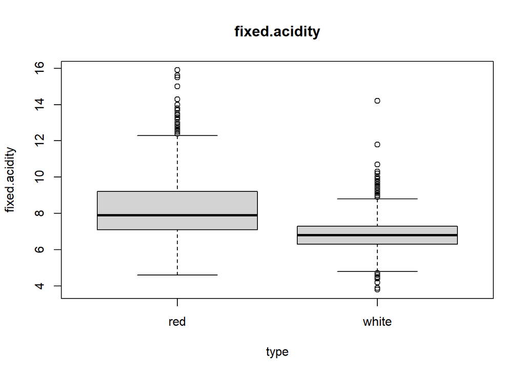

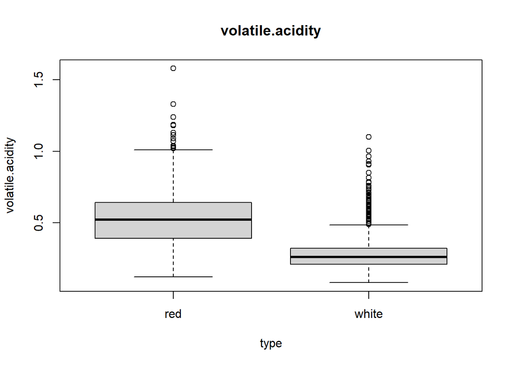

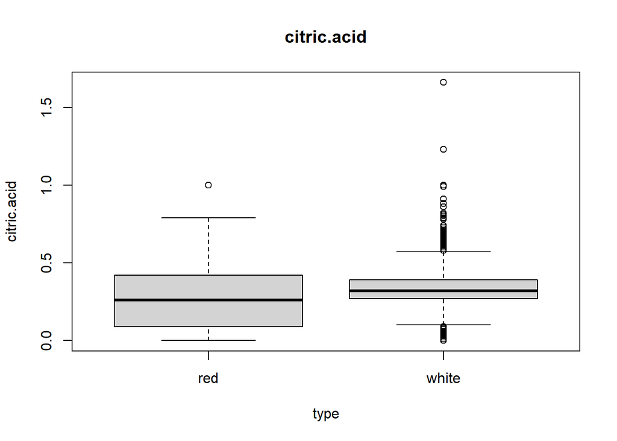

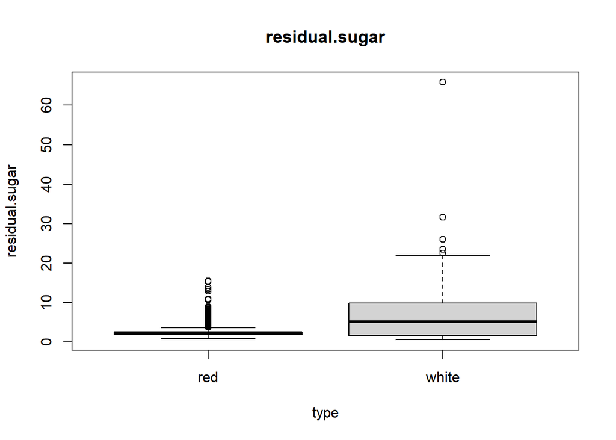

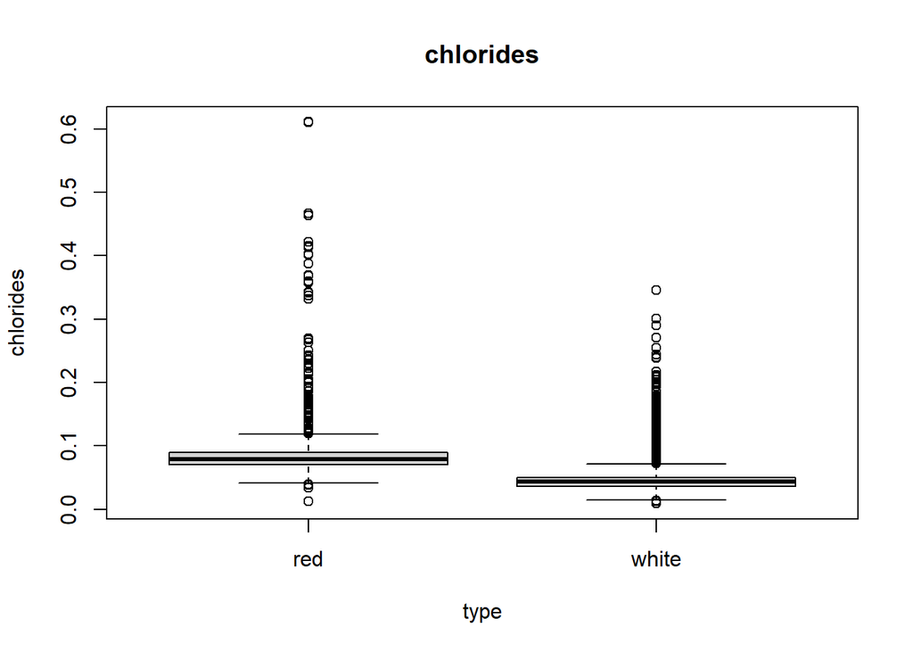

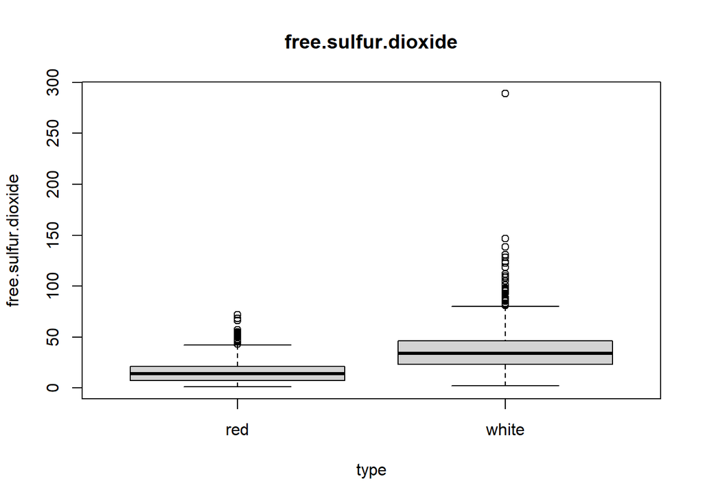

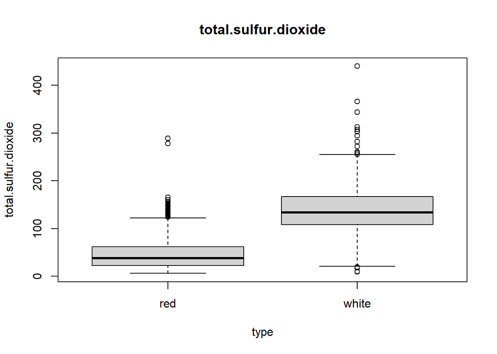

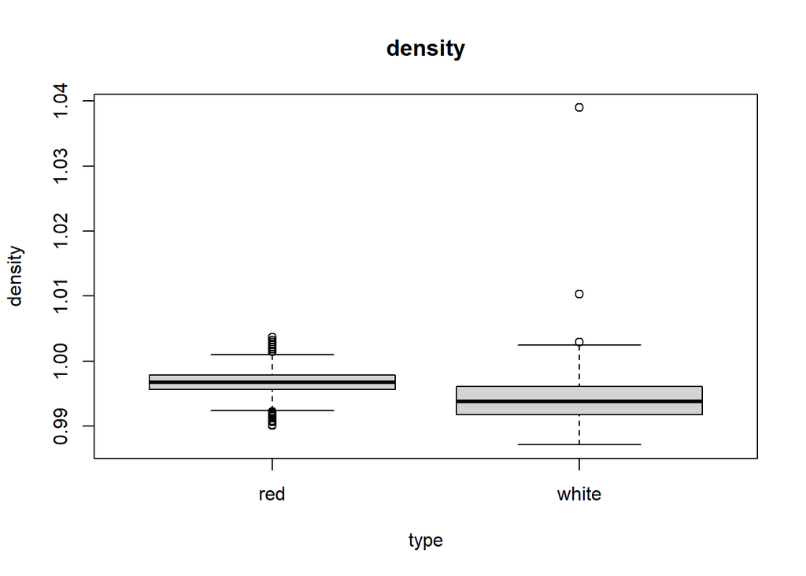

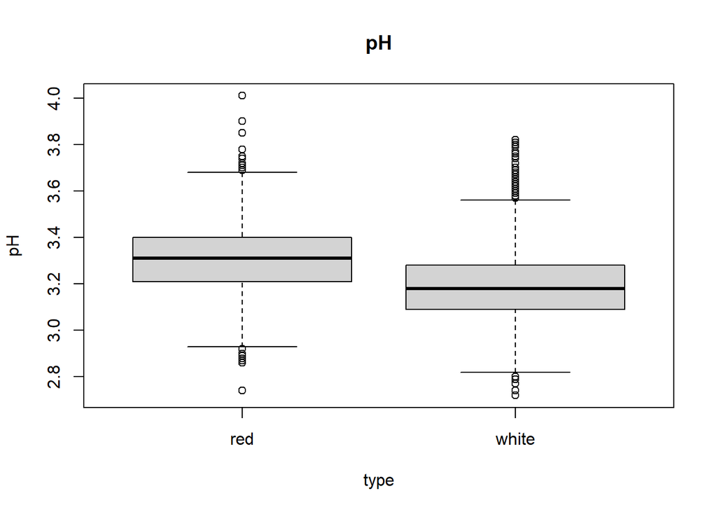

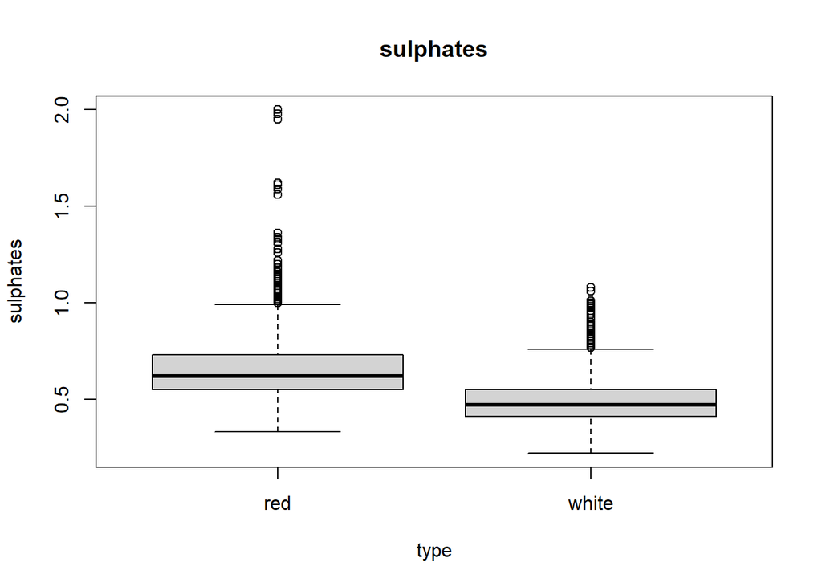

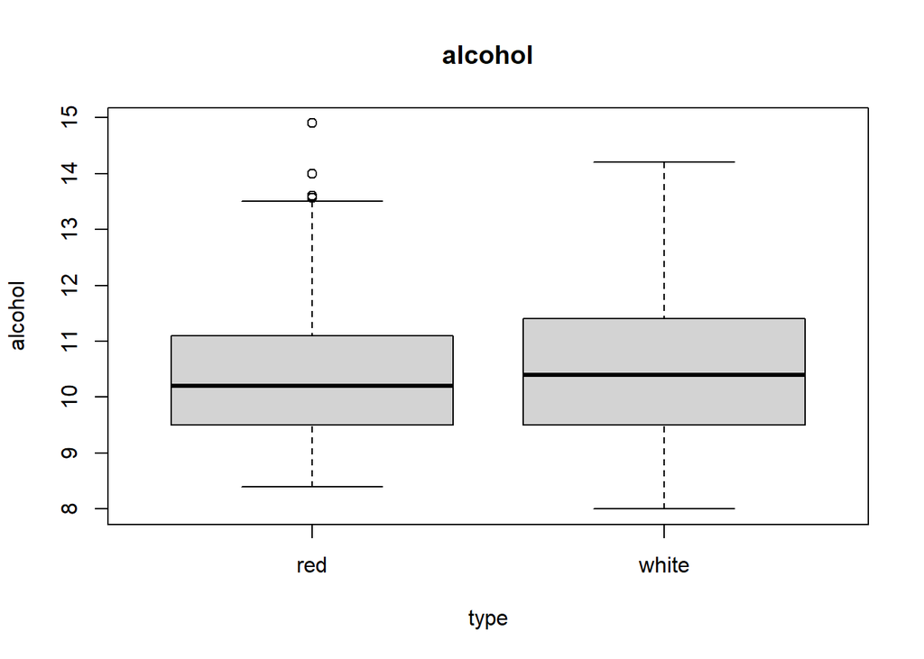

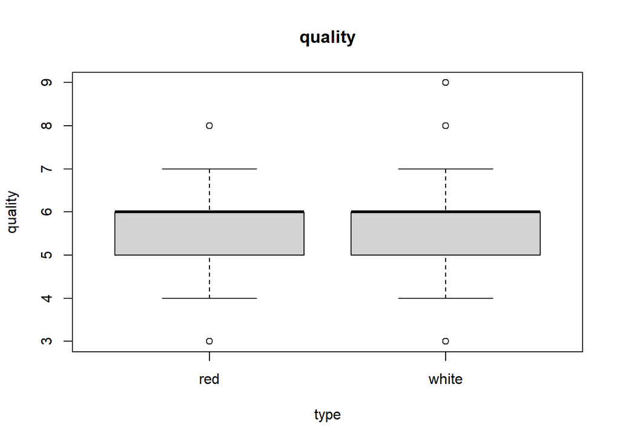

```r
# Variable amb el nom de les diferents columnes
cols <- colnames(wine)[1:12]

# Crea boxplots per als vins de tipus 'red' i 'white' per a cada variable
for (i in cols){
  boxplot(wine[,i] ~ type, data=wine, ylab=i, main=i)
}
```

Veiem que en totes les variables mitjançant el mètode boxplot es detecten diversos outliers. Tot i això, aquests no estan exssesivament allunyats, cosa que fa pensar que es tracta de valors vàlids i no erronis. Tot i això, visualment es detecten alguns valors que sí que estan molt allunyats de la resta, i s’analitzaran més profundament a continuació.

### fixed.acidity

```r
# Mostra els valors detectats com a atípics
boxplot.stats(wine[which(wine$type == 'white'), names(wine)]$fixed.acidity)$out
```

```
##   [1]  9.8  9.8 10.2  9.1 10.0  9.2  9.2  9.0  9.1  9.2 10.3  9.4  9.2  9.8  9.6
##  [16]  9.2  9.0  9.3  9.2  9.1  8.9  9.8  8.9  9.2  9.7  9.4 10.3  9.6  9.0  9.7
##  [31]  9.2  9.4  9.6  9.2  9.0  9.2 10.7 10.7  9.0  9.2  9.8  9.2 14.2  8.9  8.9
##  [46]  9.1  9.1  9.8  9.0  9.3  8.9  9.0  9.0  8.9  9.0  9.3  9.2  9.6  9.4  9.4
##  [61] 10.0  8.9  8.9 10.0  9.2  9.2  9.2  9.9  9.5  9.0  9.0  8.9  9.5 11.8  9.4
##  [76]  9.1  9.8  9.9  9.2  8.9  9.2  9.4  9.4  9.4  4.6  8.9  9.4  9.2  9.2  9.8
##  [91]  9.0  9.0  9.0  8.9  8.9  4.5  9.2  9.6  4.2  9.7  9.7  9.0  4.2  9.4  8.9
## [106]  8.9  8.9  4.7  4.7  3.8  4.4  4.7  9.0  9.0  4.7  4.4  3.9  4.7  4.4
```

```r
# Mostra la fila amb el valor atípic
out_row <- which(wine$fixed.acidity == 14.2)

wine[out_row,]
```

|  | fixed.acidity | volatile.acidity | citric.acid | residual.sugar | chlorides | free.sulfur.dioxide | total.sulfur.dioxide | density | pH | sulphates | alcohol | quality | type |
| --- | --- | --- | --- | --- | --- | --- | --- | --- | --- | --- | --- | --- | --- |
| 3126 | 14.2 | 0.27 | 0.49 | 1.1 | 0.037 | 33 | 156 | 0.992 | 3.15 | 0.54 | 11.1 | 6 | white |

### volatile.acidity

```r
# Mostra els valors detectats com a atípics
boxplot.stats(wine[which(wine$type == 'red'), names(wine)]$volatile.acidity)$out
```

```
##  [1] 1.130 1.020 1.070 1.330 1.330 1.040 1.090 1.040 1.240 1.185 1.020 1.035
## [13] 1.025 1.115 1.020 1.020 1.580 1.180 1.040
```

```r
# Mostra la fila amb el valor atípic
out_row <- which(wine$volatile.acidity == 1.580)

wine[out_row,]
```

|  | fixed.acidity | volatile.acidity | citric.acid | residual.sugar | chlorides | free.sulfur.dioxide | total.sulfur.dioxide | density | pH | sulphates | alcohol | quality | type |
| --- | --- | --- | --- | --- | --- | --- | --- | --- | --- | --- | --- | --- | --- |
| 1300 | 7.6 | 1.58 | 0 | 2.1 | 0.137 | 5 | 9 | 0.99476 | 3.5 | 0.4 | 10.9 | 3 | red |

### citric.acid

```r
# Mostra els valors detectats com a atípics
boxplot.stats(wine[which(wine$type == 'white'), names(wine)]$citric.acid)$out
```

```
##   [1] 0.62 0.04 0.59 0.07 0.03 0.61 0.62 0.63 0.61 0.62 0.63 0.66 0.66 0.00 0.04
##  [16] 0.67 0.67 0.04 0.04 0.07 0.88 0.08 0.59 0.07 0.07 0.07 0.07 0.58 0.70 0.00
##  [31] 0.00 0.60 0.07 0.09 0.04 0.62 0.58 0.62 0.70 0.62 0.62 0.58 0.02 0.65 0.65
##  [46] 0.71 0.66 0.66 0.07 0.06 0.07 0.06 0.68 0.68 0.68 0.68 0.06 0.72 0.69 0.58
##  [61] 0.70 1.66 0.04 0.63 0.60 0.00 0.08 0.58 0.58 0.05 0.58 0.00 0.00 0.65 0.58
##  [76] 0.00 0.05 0.05 0.62 0.62 0.58 0.58 1.00 0.09 0.01 0.71 0.71 0.60 0.06 0.74
##  [91] 0.81 0.69 0.58 0.69 0.00 0.07 0.64 0.72 0.73 0.65 0.68 0.65 0.74 0.71 0.59
## [106] 0.68 0.08 0.72 0.64 0.02 0.74 0.74 0.74 0.74 0.74 0.74 0.74 0.74 0.74 0.74
## [121] 0.74 0.74 0.74 0.74 0.74 0.74 0.74 0.74 0.74 0.74 0.74 0.99 0.74 0.74 0.74
## [136] 0.74 0.74 0.74 0.74 0.74 0.74 0.74 0.74 0.74 0.74 0.74 0.01 0.74 0.01 0.74
## [151] 0.74 1.00 0.04 0.58 0.07 1.00 0.00 0.58 0.61 0.61 0.61 0.02 0.67 0.67 0.67
## [166] 0.58 0.65 0.58 0.09 0.08 0.71 0.04 0.03 0.05 0.64 0.64 0.58 0.58 0.81 0.58
## [181] 0.61 0.62 0.59 0.00 0.04 0.63 0.73 0.68 0.09 0.78 0.79 0.09 0.64 0.65 0.65
## [196] 0.00 0.73 0.73 0.64 0.60 0.71 0.72 0.82 0.07 0.58 0.58 1.00 0.66 0.80 0.80
## [211] 1.23 0.59 0.02 0.00 1.00 0.62 0.00 0.71 0.71 0.71 0.61 0.61 0.00 0.60 0.58
## [226] 0.09 0.09 0.72 0.62 0.62 0.79 0.82 0.67 0.01 0.01 0.86 0.61 0.02 0.05 0.00
## [241] 0.69 0.69 0.59 0.01 0.66 0.66 0.78 0.00 0.04 0.91 0.91 0.06 0.06 0.04 0.04
## [256] 0.74 0.09 0.09 0.60 0.62 0.73 0.00 0.09 0.00 0.09 0.67 0.01 0.09 0.00 0.02
```

```r
# Mostra la fila amb el valor atípic
out_row <- which(wine$citric.acid == 1.66)

wine[out_row,]
```

|  | fixed.acidity | volatile.acidity | citric.acid | residual.sugar | chlorides | free.sulfur.dioxide | total.sulfur.dioxide | density | pH | sulphates | alcohol | quality | type |
| --- | --- | --- | --- | --- | --- | --- | --- | --- | --- | --- | --- | --- | --- |
| 2345 | 7.4 | 0.2 | 1.66 | 2.1 | 0.022 | 34 | 113 | 0.99165 | 3.26 | 0.55 | 12.2 | 6 | white |

### residual.sugar

```r
# Mostra els valors detectats com a atípics
boxplot.stats(wine[which(wine$type == 'white'), names(wine)]$residual.sugar)$out
```

```
## [1] 23.50 31.60 31.60 65.80 26.05 26.05 22.60
```

```r
# Mostra la fila amb el valor atípic
out_row <- which(wine$residual.sugar == 65.80)

wine[out_row,]
```

|  | fixed.acidity | volatile.acidity | citric.acid | residual.sugar | chlorides | free.sulfur.dioxide | total.sulfur.dioxide | density | pH | sulphates | alcohol | quality | type |
| --- | --- | --- | --- | --- | --- | --- | --- | --- | --- | --- | --- | --- | --- |
| 4381 | 7.8 | 0.965 | 0.6 | 65.8 | 0.074 | 8 | 160 | 1.03898 | 3.39 | 0.69 | 11.7 | 6 | white |

### chlorides

```r
# Mostra els valors detectats com a atípics
boxplot.stats(wine[which(wine$type == 'red'), names(wine)]$chlorides)$out
```

```
##   [1] 0.176 0.170 0.368 0.341 0.172 0.332 0.464 0.401 0.467 0.122 0.178 0.146
##  [13] 0.236 0.610 0.360 0.270 0.039 0.337 0.263 0.611 0.358 0.343 0.186 0.213
##  [25] 0.214 0.121 0.122 0.122 0.128 0.120 0.159 0.124 0.122 0.122 0.174 0.121
##  [37] 0.127 0.413 0.152 0.152 0.125 0.122 0.200 0.171 0.226 0.226 0.250 0.148
##  [49] 0.122 0.124 0.124 0.143 0.222 0.039 0.157 0.422 0.034 0.387 0.415 0.157
##  [61] 0.157 0.243 0.241 0.190 0.132 0.126 0.038 0.165 0.145 0.147 0.012 0.012
##  [73] 0.039 0.194 0.132 0.161 0.120 0.120 0.123 0.123 0.414 0.216 0.171 0.178
##  [85] 0.369 0.166 0.166 0.136 0.132 0.132 0.123 0.123 0.123 0.403 0.137 0.414
##  [97] 0.166 0.168 0.415 0.153 0.415 0.267 0.123 0.214 0.214 0.169 0.205 0.205
## [109] 0.039 0.235 0.230 0.038
```

```r
# Mostra la fila amb el valor atípic
out_row <- which(wine$chlorides >= 0.6)

wine[out_row,]
```

|  | fixed.acidity | volatile.acidity | citric.acid | residual.sugar | chlorides | free.sulfur.dioxide | total.sulfur.dioxide | density | pH | sulphates | alcohol | quality | type |
| --- | --- | --- | --- | --- | --- | --- | --- | --- | --- | --- | --- | --- | --- |
| 152 | 9.2 | 0.52 | 1.00 | 3.4 | 0.610 | 32 | 69 | 0.9996 | 2.74 | 2.00 | 9.4 | 4 | red |
| 259 | 7.7 | 0.41 | 0.76 | 1.8 | 0.611 | 8 | 45 | 0.9968 | 3.06 | 1.26 | 9.4 | 5 | red |

### free.sulfur.dioxide

```r
# Mostra els valors detectats com a atípics
#boxplot.stats(wine$free.sulfur.dioxide)$out
boxplot.stats(wine[which(wine$type == 'white'), names(wine)]$free.sulfur.dioxide)$out
```

```
##  [1]  81.0  82.0 131.0  82.5  87.0  87.0  83.0 122.5  83.0  81.0  88.0  82.0
## [13] 118.5  81.0  96.0  83.0  83.0 146.5 128.0 110.0  85.0  89.0  86.0  86.0
## [25]  96.0  96.0  93.0  85.0  81.0 138.5  95.0 124.0  87.0  87.0 105.0 105.0
## [37] 101.0 101.0 108.0 108.0  98.0  98.0 112.0 108.0  98.0  81.0  81.0  81.0
## [49] 289.0  97.0
```

```r
# Mostra la fila amb el valor atípic
out_row <- which(wine$free.sulfur.dioxide == 289)

wine[out_row,]
```

|  | fixed.acidity | volatile.acidity | citric.acid | residual.sugar | chlorides | free.sulfur.dioxide | total.sulfur.dioxide | density | pH | sulphates | alcohol | quality | type |
| --- | --- | --- | --- | --- | --- | --- | --- | --- | --- | --- | --- | --- | --- |
| 6345 | 6.1 | 0.26 | 0.25 | 2.9 | 0.047 | 289 | 440 | 0.99314 | 3.44 | 0.64 | 10.5 | 3 | white |

### total.sulfur.dioxide

```r
# Mostra els valors detectats com a atípics
boxplot.stats(wine[which(wine$type == 'red'), names(wine)]$total.sulfur.dioxide)$out
```

```
##  [1] 145 148 136 125 140 136 133 153 134 141 129 128 129 128 143 144 127 126 145
## [20] 144 135 165 124 124 134 124 129 151 133 142 149 147 145 148 155 151 152 125
## [39] 127 139 143 144 130 278 289 135 160 141 141 133 147 147 131 131 131
```

```r
# Mostra la fila amb el valor atípic
out_row <- which(wine[which(wine$type == 'red'), names(wine)]$total.sulfur.dioxide >= 200)

wine[out_row,]
```

|  | fixed.acidity | volatile.acidity | citric.acid | residual.sugar | chlorides | free.sulfur.dioxide | total.sulfur.dioxide | density | pH | sulphates | alcohol | quality | type |
| --- | --- | --- | --- | --- | --- | --- | --- | --- | --- | --- | --- | --- | --- |
| 1080 | 7.9 | 0.3 | 0.68 | 8.3 | 0.05 | 37.5 | 278 | 0.99316 | 3.01 | 0.51 | 12.3 | 7 | red |
| 1082 | 7.9 | 0.3 | 0.68 | 8.3 | 0.05 | 37.5 | 289 | 0.99316 | 3.01 | 0.51 | 12.3 | 7 | red |

### density

```r
# Mostra els valors detectats com a atípics
boxplot.stats(wine[which(wine$type == 'white'), names(wine)]$density)$out
```

```
## [1] 1.01030 1.01030 1.03898 1.00295 1.00295
```

```r
# Mostra la fila amb el valor atípic
out_row <- which(wine$density == 1.03898)

wine[out_row,]
```

|  | fixed.acidity | volatile.acidity | citric.acid | residual.sugar | chlorides | free.sulfur.dioxide | total.sulfur.dioxide | density | pH | sulphates | alcohol | quality | type |
| --- | --- | --- | --- | --- | --- | --- | --- | --- | --- | --- | --- | --- | --- |
| 4381 | 7.8 | 0.965 | 0.6 | 65.8 | 0.074 | 8 | 160 | 1.03898 | 3.39 | 0.69 | 11.7 | 6 | white |

### sulphates

```r
# Mostra els valors detectats com a atípics
boxplot.stats(wine[which(wine$type == 'red'), names(wine)]$sulphates)$out
```

```
##  [1] 1.56 1.28 1.08 1.20 1.12 1.28 1.14 1.95 1.22 1.95 1.98 1.31 2.00 1.08 1.59
## [16] 1.02 1.03 1.61 1.09 1.26 1.08 1.00 1.36 1.18 1.13 1.04 1.11 1.13 1.07 1.06
## [31] 1.06 1.05 1.06 1.04 1.05 1.02 1.14 1.02 1.36 1.36 1.05 1.17 1.62 1.06 1.18
## [46] 1.07 1.34 1.16 1.10 1.15 1.17 1.17 1.33 1.18 1.17 1.03 1.17 1.10 1.01
```

```r
# Mostra la fila amb el valor atípic
out_row <- which(wine$sulphates >= 1.9)

wine[out_row,]
```

|  | fixed.acidity | volatile.acidity | citric.acid | residual.sugar | chlorides | free.sulfur.dioxide | total.sulfur.dioxide | density | pH | sulphates | alcohol | quality | type |
| --- | --- | --- | --- | --- | --- | --- | --- | --- | --- | --- | --- | --- | --- |
| 87 | 8.6 | 0.49 | 0.28 | 1.9 | 0.11 | 20 | 136 | 0.9972 | 2.93 | 1.95 | 9.9 | 6 | red |
| 92 | 8.6 | 0.49 | 0.28 | 1.9 | 0.11 | 20 | 136 | 0.9972 | 2.93 | 1.95 | 9.9 | 6 | red |
| 93 | 8.6 | 0.49 | 0.29 | 2.0 | 0.11 | 19 | 133 | 0.9972 | 2.93 | 1.98 | 9.8 | 5 | red |
| 152 | 9.2 | 0.52 | 1.00 | 3.4 | 0.61 | 32 | 69 | 0.9996 | 2.74 | 2.00 | 9.4 | 4 | red |

Aquests valors, tot i que no tenen per què ser no vàlids, representen uns vins amb unes caracterítiques molt diferents a les de la resta del conjunt de dades, per tant, com que són pocs casos s’ha decidit eliminar-los del dataframe per evitar que impactin negativament en l’etapa de l’anàlisi.

```r
# Elimina les files amb valors extrems
wine <- wine[-c(3126, 1300, 2345, 4381, 152, 259, 6346, 1080, 1082, 87, 92, 93),]
```

# 4. Anàlisi de les dades

## 4.1. Selecció dels grups de dades que es volen analitzar/comparar

S’explora la variable dependent quality, per veure si està equilibrada.

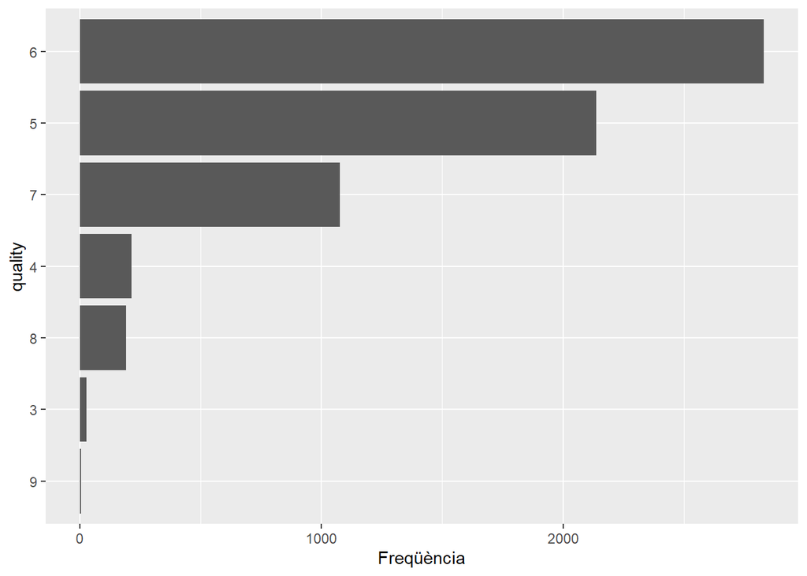

```r
# Visualitza la freqüència de les puntuacions de qualitat
ggplot(wine, aes(x = reorder(quality, quality, function(x) length(x)))) + geom_bar() + xlab("quality") + ylab("Freqüència") + coord_flip()
```

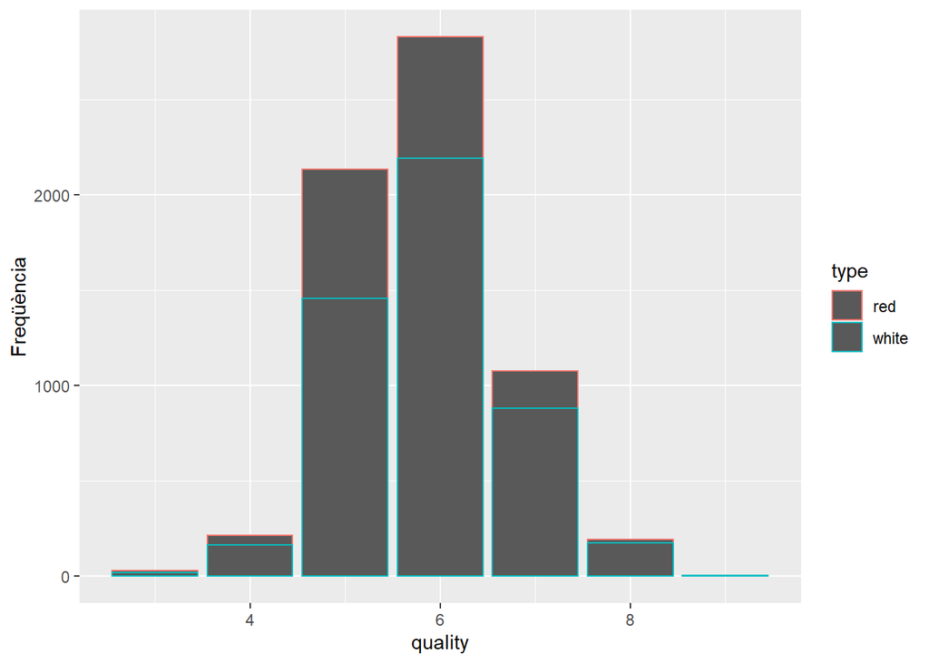

```r
# Visualitza la freqüència de la qualitat segons el tipus de vi
ggplot() + geom_bar(data = wine, aes(x = quality, color = type)) + ylab("Freqüència")
```

Hi ha molts vins amb valoracions intermedies, però molt pocs amb valoracions molt altes o molt baixes, així que s’ha decidit eliminar els vins amb puntuacions de 9 i 3 degut a la seva poca presencia.

```r
# Mostra el nombre de vins amb qualitat 9 o 3
sum(wine$quality == 9)
```

```
## [1] 5
```

```r
sum(wine$quality == 3)
```

```
## [1] 29
```

```r
# Elimina les files amb qualitat 9
wine <- wine[-c(which(wine$quality == 9)),]
# Elimina les files amb qualitat 3
wine <- wine[-c(which(wine$quality == 3)),]
```

### Correlació

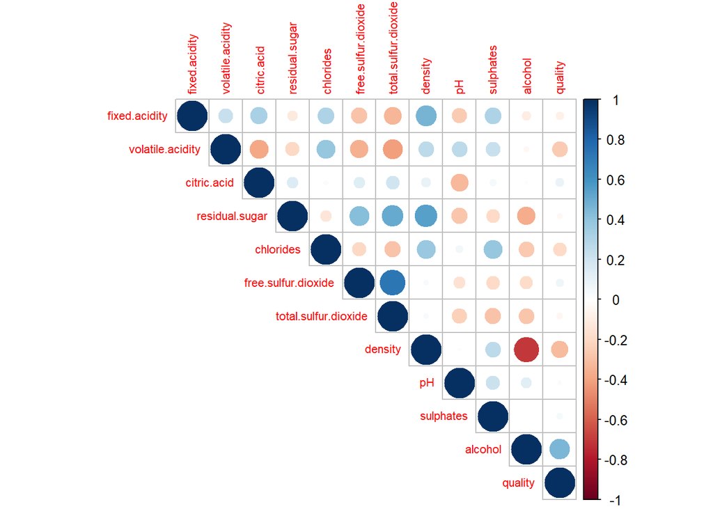

```r
# Calcula la correlació i ho visualitza en un gràfic
wine_corr <- cor(wine[,c(1:12)])
corrplot(wine_corr, method='circle', type='upper', tl.cex=0.7)
```

```r
# Elimina la columna no rellevant free.sulfur.dioxide
wine <- wine[-6]

# Mostra com ha quedat el nou data.frame
str(wine)
```

```
## 'data.frame':    6451 obs. of  12 variables:
##  $ fixed.acidity       : num  7.4 7.8 7.8 11.2 7.4 7.4 7.9 7.3 7.8 7.5 ...
##  $ volatile.acidity    : num  0.7 0.88 0.76 0.28 0.7 0.66 0.6 0.65 0.58 0.5 ...
##  $ citric.acid         : num  0 0 0.04 0.56 0 0 0.06 0 0.02 0.36 ...
##  $ residual.sugar      : num  1.9 2.6 2.3 1.9 1.9 1.8 1.6 1.2 2 6.1 ...
##  $ chlorides           : num  0.076 0.098 0.092 0.075 0.076 0.075 0.069 0.065 0.073 0.071 ...
##  $ total.sulfur.dioxide: num  34 67 54 60 34 40 59 21 18 102 ...
##  $ density             : num  0.998 0.997 0.997 0.998 0.998 ...
##  $ pH                  : num  3.51 3.2 3.26 3.16 3.51 3.51 3.3 3.39 3.36 3.35 ...
##  $ sulphates           : num  0.56 0.68 0.65 0.58 0.56 0.56 0.46 0.47 0.57 0.8 ...
##  $ alcohol             : num  9.4 9.8 9.8 9.8 9.4 9.4 9.4 10 9.5 10.5 ...
##  $ quality             : int  5 5 5 6 5 5 5 7 7 5 ...
##  $ type                : Factor w/ 2 levels "red","white": 1 1 1 1 1 1 1 1 1 1 ...
```

El data.frame resultant consta de 6.451 observacions i 12 variables. Les 10 primeres són les variables independents, i les dues últimes són les variables independents. Els grups que es volen comparar són els dels vins “red” o “white”, de la variable type a partir de less caracterítiques fisicoquímiques dels vins, així que la variable quality no es tindrà en compte.

## 4.2. Comprovació de la normalitat i homogeneïtat de la variància.

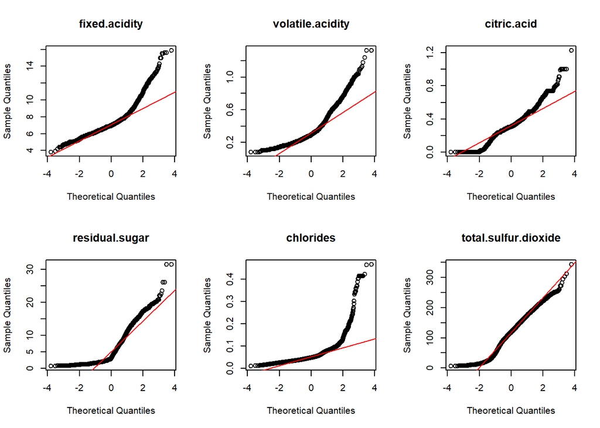

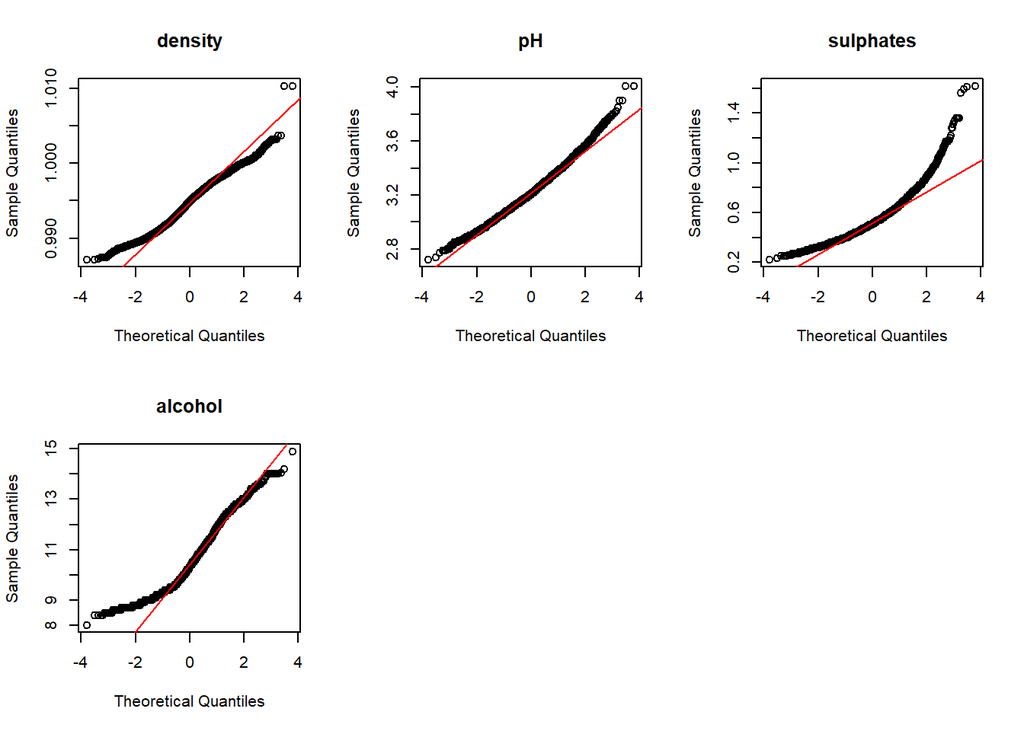

```r
# Variable amb el nom de les diferents columnes
cols <- colnames(wine)[1:10]

# Creació d'una quadricula de 2 files i 3 columnes per als gràfics
par(mfrow=c(2,3))

# Inspecció visual mitjançant plots Q-Q per a cada variable
for (i in cols){
  qqnorm(wine[,i], main=i)
  qqline(wine[,i], col='red')
}
```

Es pot observar que els punts no coincideixen perfectament amb les linies, això significa que les variables no segueixen uns distribució normal. A continuació s’analitza més profundament cada variable.

### Variable fixed.acidity

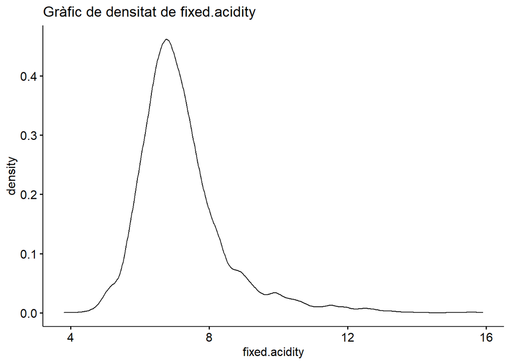

```r
# Inspecció visual mitjançant un plot de densitat
ggdensity(wine$fixed.acidity,
          main = 'Gràfic de densitat de fixed.acidity',
          xlab = 'fixed.acidity')
```

Per a fer els tests de normalitat de Shapiro-Wilk la mida de la mostra ha de ser entre 3 i 5000 així que agafarem una mostra aleatòria de 5000 observacions del dataframe.

```r
set.seed(10)

# Crea una mostra aleatòria de 5000 observacions
index <- sample(1:nrow(wine), 5000)
wine_sample <- wine[index,]
```

```r
# Test de normalitat de Shapiro-Wilk
shapiro.test(wine_sample$fixed.acidity)
```

```
##
##  Shapiro-Wilk normality test
##
## data:  wine_sample$fixed.acidity
## W = 0.87574, p-value < 2.2e-16
```

```r
# Crea subsets diferenciant entre vins "red" i "white"
wine.red <- subset(wine, type == 'red')
wine.white <- subset(wine, type == 'white')

# Comprova si les variàncies són iguals
var.test(wine.red$fixed.acidity, wine.white$fixed.acidity)
```

```
##
##  F test to compare two variances
##
## data:  wine.red$fixed.acidity and wine.white$fixed.acidity
## F = 4.4136, num df = 1581, denom df = 4868, p-value < 2.2e-16
## alternative hypothesis: true ratio of variances is not equal to 1
## 95 percent confidence interval:
##  4.076612 4.786423
## sample estimates:
## ratio of variances
##            4.41361
```

### Variable volatile.acidity

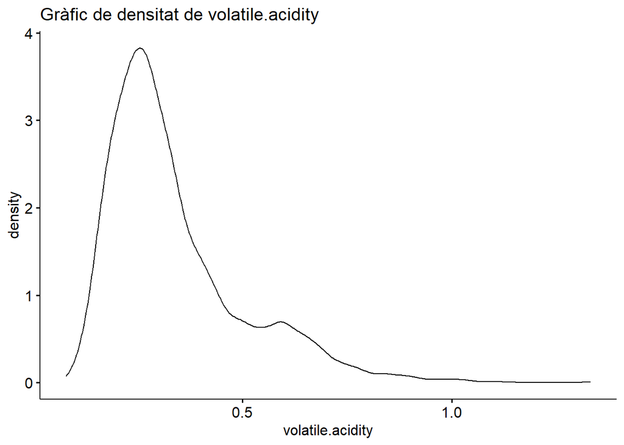

```r
# Inspecció visual mitjançant un plot de densitat
ggdensity(wine$volatile.acidity,
          main = 'Gràfic de densitat de volatile.acidity',
          xlab = 'volatile.acidity')
```

```r
# Test de normalitat de Shapiro-Wilk
shapiro.test(wine_sample$volatile.acidity)
```

```
##
##  Shapiro-Wilk normality test
##
## data:  wine_sample$volatile.acidity
## W = 0.87481, p-value < 2.2e-16
```

```r
# Comprova si les variàncies són iguals
var.test(wine.red$volatile.acidity, wine.white$volatile.acidity)
```

```
##
##  F test to compare two variances
##
## data:  wine.red$volatile.acidity and wine.white$volatile.acidity
## F = 3.081, num df = 1581, denom df = 4868, p-value < 2.2e-16
## alternative hypothesis: true ratio of variances is not equal to 1
## 95 percent confidence interval:
##  2.845755 3.341251
## sample estimates:
## ratio of variances
##           3.081002
```

### Variable citric.acid

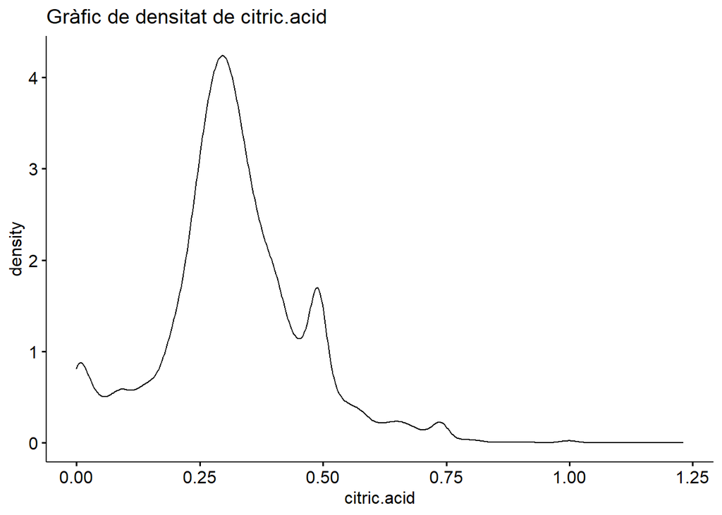

```r
# Inspecció visual mitjançant un plot de densitat
ggdensity(wine$citric.acid,
          main = 'Gràfic de densitat de citric.acid',
          xlab = 'citric.acid')
```

```r
# Test de normalitat de Shapiro-Wilk
shapiro.test(wine_sample$citric.acid)
```

```
##
##  Shapiro-Wilk normality test
##
## data:  wine_sample$citric.acid
## W = 0.97341, p-value < 2.2e-16
```

```r
# Comprova si les variàncies són iguals
var.test(wine.red$citric.acid, wine.white$citric.acid)
```

```
##
##  F test to compare two variances
##
## data:  wine.red$citric.acid and wine.white$citric.acid
## F = 2.6016, num df = 1581, denom df = 4868, p-value < 2.2e-16
## alternative hypothesis: true ratio of variances is not equal to 1
## 95 percent confidence interval:
##  2.402932 2.821326
## sample estimates:
## ratio of variances
##           2.601573
```

### Variable residual.sugar

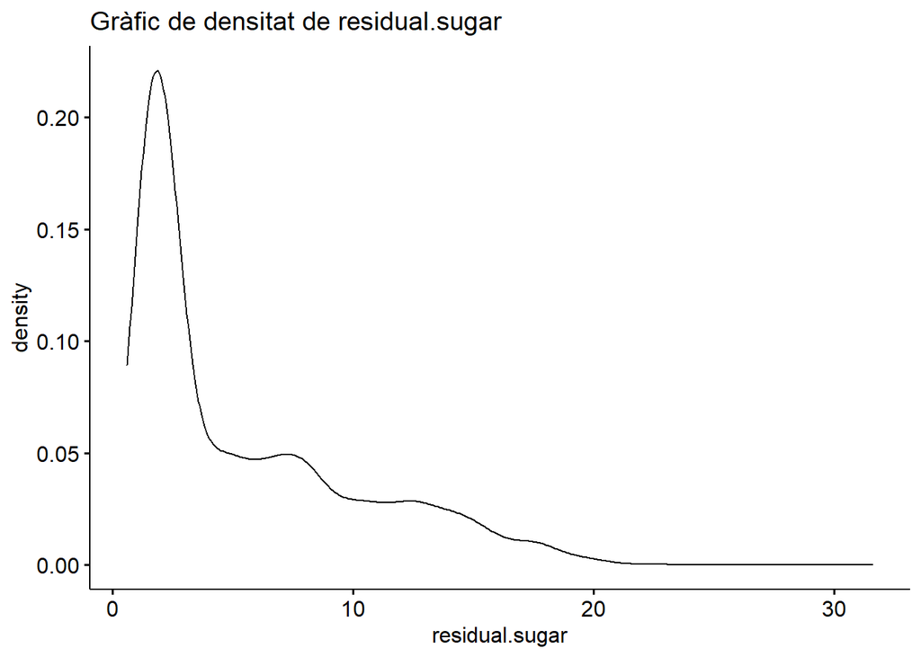

```r
# Inspecció visual mitjançant un plot de densitat
ggdensity(wine$residual.sugar,
          main = 'Gràfic de densitat de residual.sugar',
          xlab = 'residual.sugar')
```

```r
# Test de normalitat de Shapiro-Wilk
shapiro.test(wine_sample$residual.sugar)
```

```
##
##  Shapiro-Wilk normality test
##
## data:  wine_sample$residual.sugar
## W = 0.83572, p-value < 2.2e-16
```

```r
# Comprova si les variàncies són iguals
var.test(wine.red$residual.sugar, wine.white$residual.sugar)
```

```
##
##  F test to compare two variances
##
## data:  wine.red$residual.sugar and wine.white$residual.sugar
## F = 0.078136, num df = 1581, denom df = 4868, p-value < 2.2e-16
## alternative hypothesis: true ratio of variances is not equal to 1
## 95 percent confidence interval:
##  0.07217005 0.08473614
## sample estimates:
## ratio of variances
##         0.07813606
```

### Variable chlorides

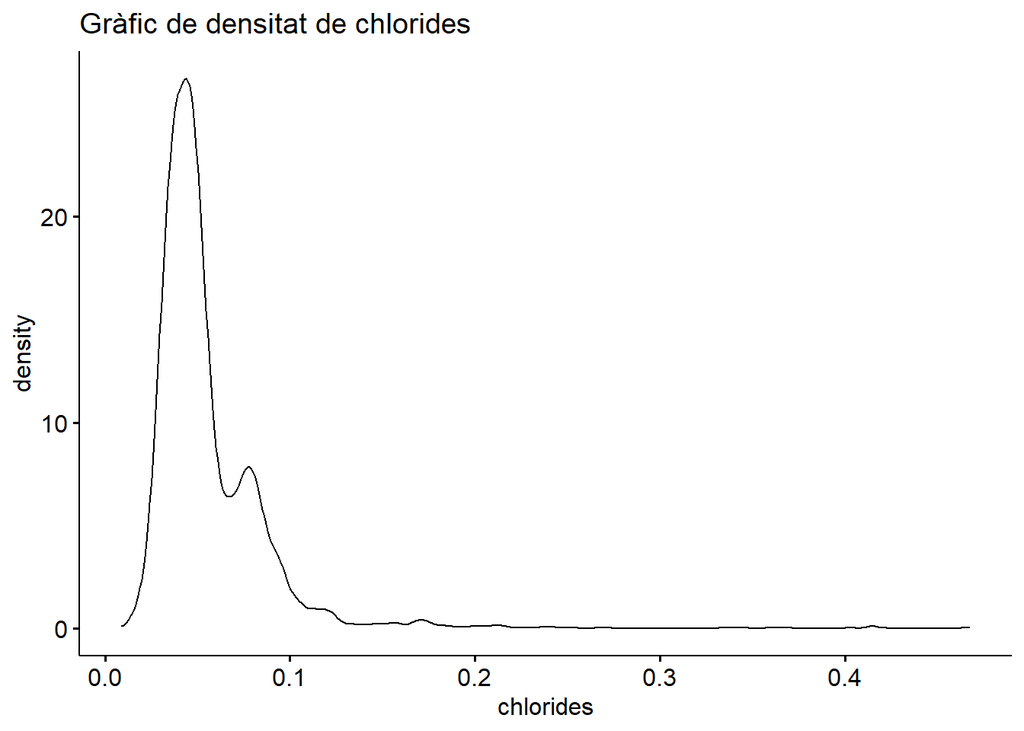

```r
# Inspecció visual mitjançant un plot de densitat
ggdensity(wine$chlorides,
          main = 'Gràfic de densitat de chlorides',
          xlab = 'chlorides')
```

```r
# Test de normalitat de Shapiro-Wilk
shapiro.test(wine_sample$chlorides)
```

```
##
##  Shapiro-Wilk normality test
##
## data:  wine_sample$chlorides
## W = 0.62952, p-value < 2.2e-16
```

```r
# Comprova si les variàncies són iguals
var.test(wine.red$chlorides, wine.white$chlorides)
```

```
##
##  F test to compare two variances
##
## data:  wine.red$chlorides and wine.white$chlorides
## F = 3.9439, num df = 1581, denom df = 4868, p-value < 2.2e-16
## alternative hypothesis: true ratio of variances is not equal to 1
## 95 percent confidence interval:
##  3.642785 4.277058
## sample estimates:
## ratio of variances
##           3.943919
```

### Variable total.sulfur.dioxide

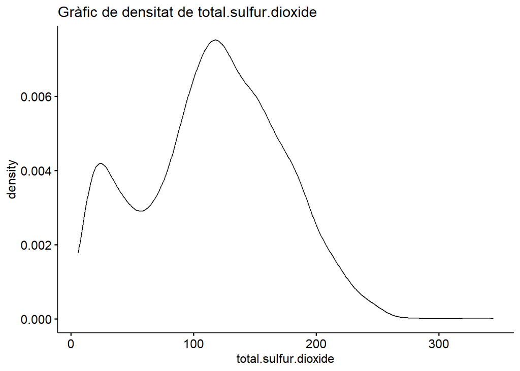

```r
# Inspecció visual mitjançant un plot de densitat
ggdensity(wine$total.sulfur.dioxide,
          main = 'Gràfic de densitat de total.sulfur.dioxide',
          xlab = 'total.sulfur.dioxide')
```

```r
# Test de normalitat de Shapiro-Wilk
shapiro.test(wine_sample$total.sulfur.dioxide)
```

```
##
##  Shapiro-Wilk normality test
##
## data:  wine_sample$total.sulfur.dioxide
## W = 0.98154, p-value < 2.2e-16
```

```r
# Comprova si les variàncies són iguals
var.test(wine.red$total.sulfur.dioxide, wine.white$total.sulfur.dioxide)
```

```
##
##  F test to compare two variances
##
## data:  wine.red$total.sulfur.dioxide and wine.white$total.sulfur.dioxide
## F = 0.56778, num df = 1581, denom df = 4868, p-value < 2.2e-16
## alternative hypothesis: true ratio of variances is not equal to 1
## 95 percent confidence interval:
##  0.5244248 0.6157365
## sample estimates:
## ratio of variances
##           0.567777
```

### Variable density

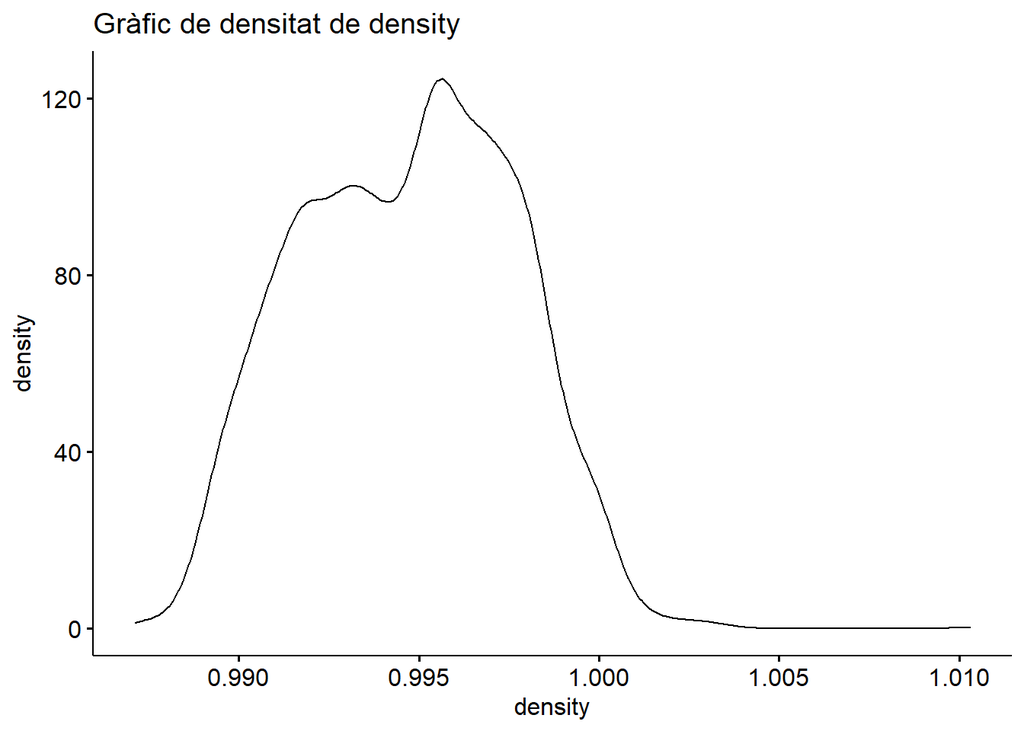

```r
# Inspecció visual mitjançant un plot de densitat
ggdensity(wine$density,
          main = 'Gràfic de densitat de density',
          xlab = 'density')
```

```r
# Test de normalitat de Shapiro-Wilk
shapiro.test(wine_sample$density)
```

```
##
##  Shapiro-Wilk normality test
##
## data:  wine_sample$density
## W = 0.98563, p-value < 2.2e-16
```

```r
# Comprova si les variàncies són iguals
var.test(wine.red$density, wine.white$density)
```

```
##
##  F test to compare two variances
##
## data:  wine.red$density and wine.white$density
## F = 0.41636, num df = 1581, denom df = 4868, p-value < 2.2e-16
## alternative hypothesis: true ratio of variances is not equal to 1
## 95 percent confidence interval:
##  0.3845679 0.4515281
## sample estimates:
## ratio of variances
##          0.4163587
```

### Variable pH

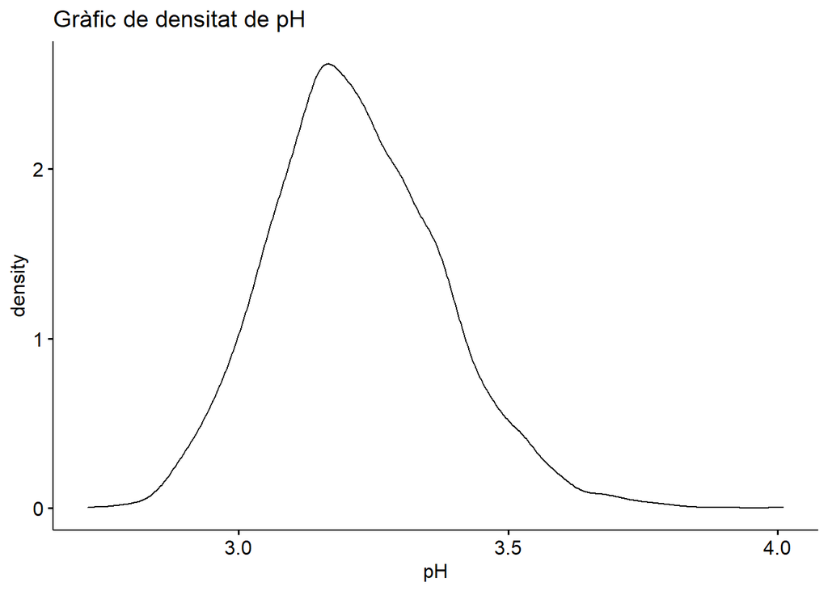

```r
# Inspecció visual mitjançant un plot de densitat
ggdensity(wine$pH,
          main = 'Gràfic de densitat de pH',
          xlab = 'pH')
```

```r
# Test de normalitat de Shapiro-Wilk
shapiro.test(wine_sample$pH)
```

```
##
##  Shapiro-Wilk normality test
##
## data:  wine_sample$pH
## W = 0.99135, p-value < 2.2e-16
```

```r
# Comprova si les variàncies són iguals
var.test(wine.red$pH, wine.white$pH)
```

```
##
##  F test to compare two variances
##
## data:  wine.red$pH and wine.white$pH
## F = 1.0253, num df = 1581, denom df = 4868, p-value = 0.536
## alternative hypothesis: true ratio of variances is not equal to 1
## 95 percent confidence interval:
##  0.9470294 1.1119241
## sample estimates:
## ratio of variances
##           1.025317
```

### Variable sulphates

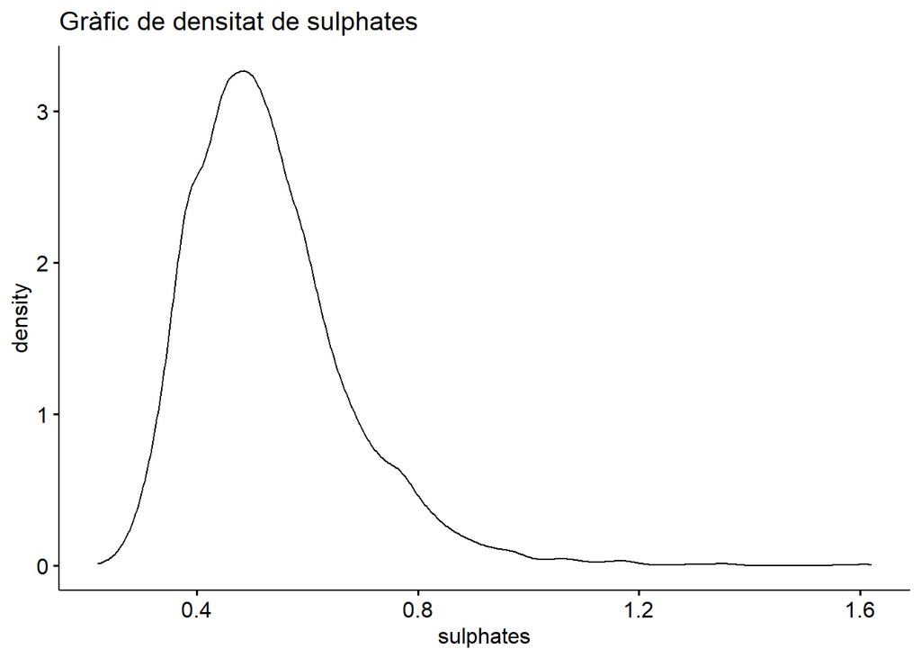

```r
# Inspecció visual mitjançant un plot de densitat
ggdensity(wine$sulphates,
          main = 'Gràfic de densitat de sulphates',
          xlab = 'sulphates')
```

```r
# Test de normalitat de Shapiro-Wilk
shapiro.test(wine_sample$sulphates)
```

```
##
##  Shapiro-Wilk normality test
##
## data:  wine_sample$sulphates
## W = 0.9201, p-value < 2.2e-16
```

```r
# Comprova si les variàncies són iguals
var.test(wine.red$sulphates, wine.white$sulphates)
```

```
##
##  F test to compare two variances
##
## data:  wine.red$sulphates and wine.white$sulphates
## F = 1.8642, num df = 1581, denom df = 4868, p-value < 2.2e-16
## alternative hypothesis: true ratio of variances is not equal to 1
## 95 percent confidence interval:
##  1.721868 2.021676
## sample estimates:
## ratio of variances
##           1.864208
```

### Variable alcohol

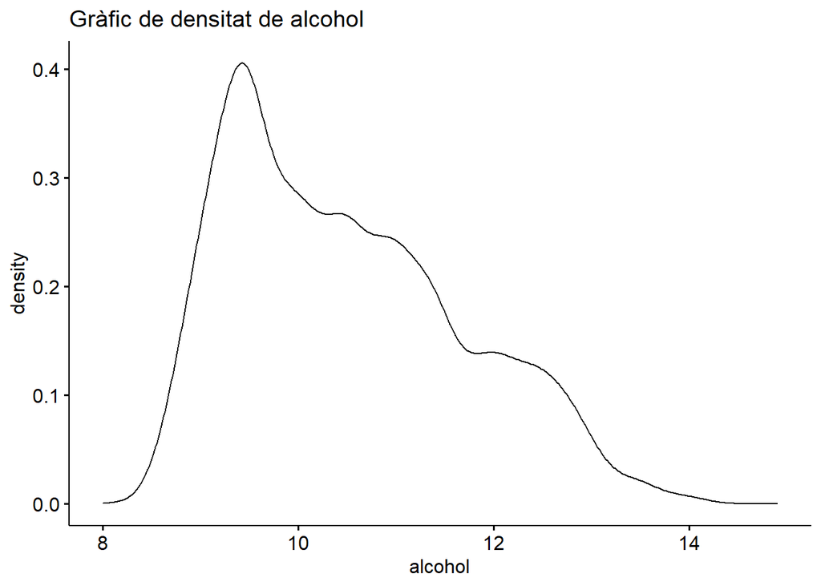

```r
# Inspecció visual mitjançant un plot de densitat
ggdensity(wine$alcohol,
          main = 'Gràfic de densitat de alcohol',
          xlab = 'alcohol')
```

```r
# Test de normalitat de Shapiro-Wilk
shapiro.test(wine_sample$alcohol)
```

```
##
##  Shapiro-Wilk normality test
##
## data:  wine_sample$alcohol
## W = 0.95254, p-value < 2.2e-16
```

```r
# Comprova si les variàncies són iguals
var.test(wine.red$alcohol, wine.white$alcohol)
```

```
##
##  F test to compare two variances
##
## data:  wine.red$alcohol and wine.white$alcohol
## F = 0.7513, num df = 1581, denom df = 4868, p-value = 1.017e-11
## alternative hypothesis: true ratio of variances is not equal to 1
## 95 percent confidence interval:
##  0.6939305 0.8147562
## sample estimates:
## ratio of variances
##           0.751295
```

El p-value en el test de normalitat de Shapiro-Wilk és inferior a 0.05 en totes les variables cosa que implica que la distribució d’aquestes és significativament diferent de la distribució normal, i per tant no podem assumir-ne la normalitat.

Tot i això, el Teorema del Límit Central diu que el contrast d’hipòtesis sobre la mitjana d’una mostra s’aproxima a una distribució normal encara que la població original no segueixi una distribució normal, sempre que la mida de la mostra sigui suficientment gran (n>30). Com que la mostra té més de 30 observacions podem aplicar el TLC.